# Group 07 Assignment02

Shameka Brayton

Paola Igarteburu

Akash Nautiyal

Brad O’Hara

Tim Raiswell

July 23rd, 2017

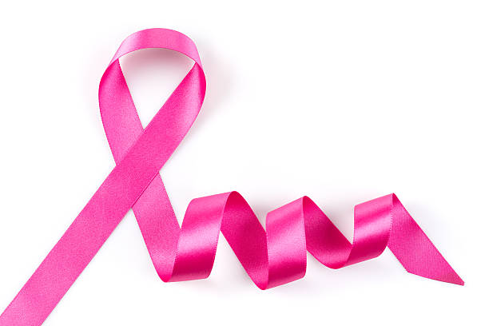

# Introduction

> For this assignment, we decided to use the University of Wisconsin Hospitals breast cancer research data found on the UCI website, gathered by Dr. William H. Wolberg. The ultimate goal of our analysis was to produce a visual aid for physicians to enable detection of maligne tumours.

# Data Deep Dive

- To begin the process, we pulled the data directly from the UCI website into a data frame.
  - The dataset is comprised of 699 images of patient breast cancer cells.
  - Each patients record tests the cells against 9 different features resulting in a classification of either benign or malignant.
  - To begin processing the data, we replaced column headers which were not included in the data.
  - We pulled the data dictionary made available by the UCI free data site. To display legibly, this process required us to perform a bit of data scrubbing.

#### Data Keys

- There are 10 features within the dataset that describe each patient. Feature 1 remains the given identity number for the patient record, while features 2 through 10 have been used to represent the instances, with a severity range of 1-10.
- Each instance has one of 2 possible classes: benign or malignant.

Data Featrues

1. Sample code number id number
2. Clump Thickness
3. Uniformity of Cell Size
4. Uniformity of Cell Shape
5. Marginal Adhesion
6. Single Epithelial Cell Size
7. Bare Nuclei
8. Bland Chromatin
9. Normal Nucleoli
10. Mitoses
11. Class:(2 for benign, 4 for malignant)

#### Data Cleansing

Top 3 Rows with Missing Data

| patientID | clump_thicknes | uniformity_cell_size | uniformity_cell_shape | marginal_adhesion | single_eipthelial | bare_nuclei | bland_chromatin | normal_nucleoli | mitoses | class |
| --- | --- | --- | --- | --- | --- | --- | --- | --- | --- | --- |
| 1057013 | 8 | 4 | 5 | 1 | 2 | NA | 7 | 3 | 1 | 4 |
| 1096800 | 6 | 6 | 6 | 9 | 6 | NA | 7 | 8 | 1 | 2 |
| 1183246 | 1 | 1 | 1 | 1 | 1 | NA | 2 | 1 | 1 | 2 |

Same 3 rows, with NA’s cleansed

| patientID | clump_thicknes | uniformity_cell_size | uniformity_cell_shape | marginal_adhesion | single_eipthelial | bare_nuclei | bland_chromatin | normal_nucleoli | mitoses | class |
| --- | --- | --- | --- | --- | --- | --- | --- | --- | --- | --- |
| 1057013 | 8 | 4 | 5 | 1 | 2 | 1 | 7 | 3 | 1 | 4 |
| 1096800 | 6 | 6 | 6 | 9 | 6 | 1 | 7 | 8 | 1 | 2 |
| 1183246 | 1 | 1 | 1 | 1 | 1 | 1 | 2 | 1 | 1 | 2 |

# Exploratory Analysis

We begin by examining the variables available in the dataset and their basic statistics.

As we can see in the following class description of each variable, they are all numeric and, specifically, integers.

|  | Data Type |
| --- | --- |
| patientID | integer |
| clump_thicknes | integer |
| uniformity_cell_size | integer |
| uniformity_cell_shape | integer |
| marginal_adhesion | integer |
| single_eipthelial | integer |
| bare_nuclei | integer |
| bland_chromatin | integer |
| normal_nucleoli | integer |
| mitoses | integer |
| class | integer |

#### Preparation for Regression

Next, we check the distribution of the data for outliers and normality ahead of a regression exercise.

```
##                       vars   n       mean        sd  median    trimmed
## patientID                1 699 1071704.10 617095.73 1171710 1091497.09
## clump_thicknes           2 699       4.42      2.82       4       4.15
## uniformity_cell_size     3 699       3.13      3.05       1       2.56
## uniformity_cell_shape    4 699       3.21      2.97       1       2.67
## marginal_adhesion        5 699       2.81      2.86       1       2.19
## single_eipthelial        6 699       3.22      2.21       2       2.78
## bare_nuclei              7 699       3.49      3.62       1       2.99
## bland_chromatin          8 699       3.44      2.44       3       3.10
## normal_nucleoli          9 699       2.87      3.05       1       2.23
## mitoses                 10 699       1.59      1.72       1       1.12
## class                   11 699       2.69      0.95       2       2.61
##                             mad   min      max    range  skew kurtosis
## patientID             154755.27 61634 13454352 13392718 13.62   255.13
## clump_thicknes             2.97     1       10        9  0.59    -0.63
## uniformity_cell_size       0.00     1       10        9  1.23     0.08
## uniformity_cell_shape      0.00     1       10        9  1.16    -0.01
## marginal_adhesion          0.00     1       10        9  1.52     0.96
## single_eipthelial          0.00     1       10        9  1.70     2.13
## bare_nuclei                0.00     1       10        9  1.02    -0.74
## bland_chromatin            1.48     1       10        9  1.10     0.17
## normal_nucleoli            0.00     1       10        9  1.42     0.45
## mitoses                    0.00     1       10        9  3.55    12.51
## class                      0.00     2        4        2  0.65    -1.58
##                             se      IQR
## patientID             23340.70 367609.5
## clump_thicknes            0.11      4.0
## uniformity_cell_size      0.12      4.0
## uniformity_cell_shape     0.11      4.0
## marginal_adhesion         0.11      3.0
## single_eipthelial         0.08      2.0
## bare_nuclei               0.14      4.0
## bland_chromatin           0.09      3.0
## normal_nucleoli           0.12      3.0
## mitoses                   0.06      0.0
## class                     0.04      2.0
```

As we can see, in most variables the mean is greater than the median. This suggests the presence of right-tail outliers in the data set (and therefore right-skew). The following histograms show this more clearly.

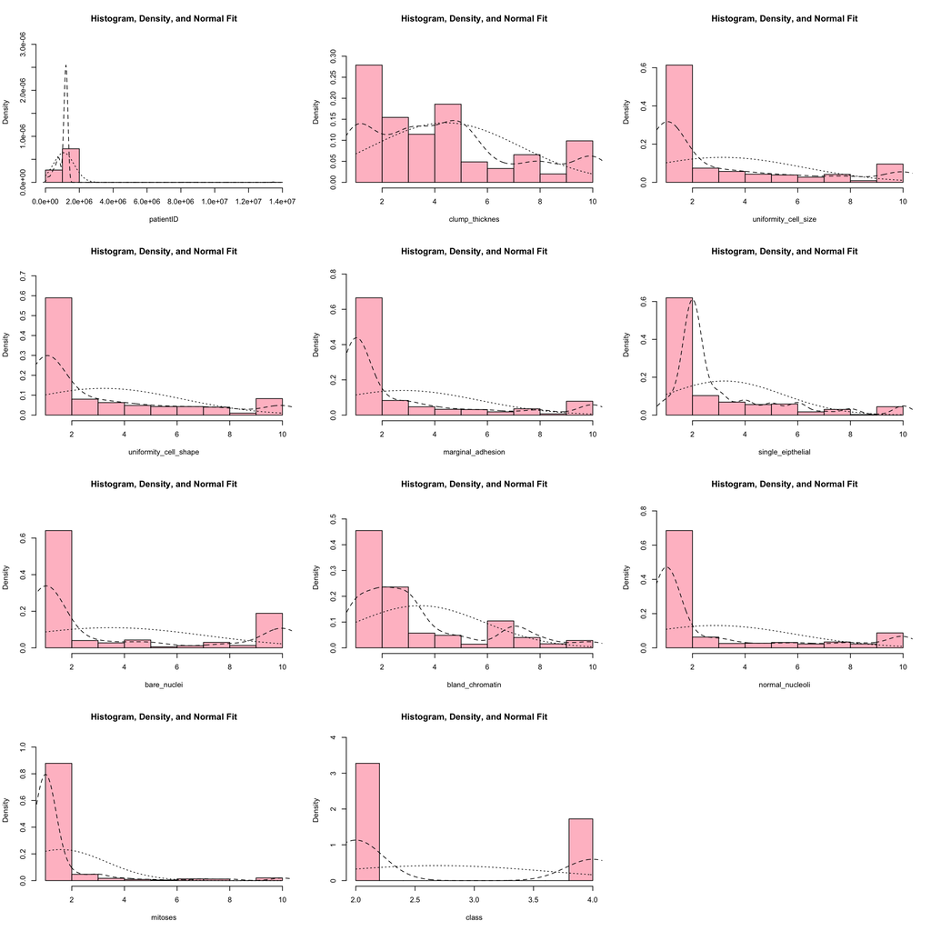

# Look for Correlations

After performing data cleaning tasks, we decided to look for correlations among the different variables available. If no correlation is observed, producing a visualization based on available features would not be valuable for physicians. In the following visualization, it becomes clear that there are several strong linear and positive relationships between available variables.

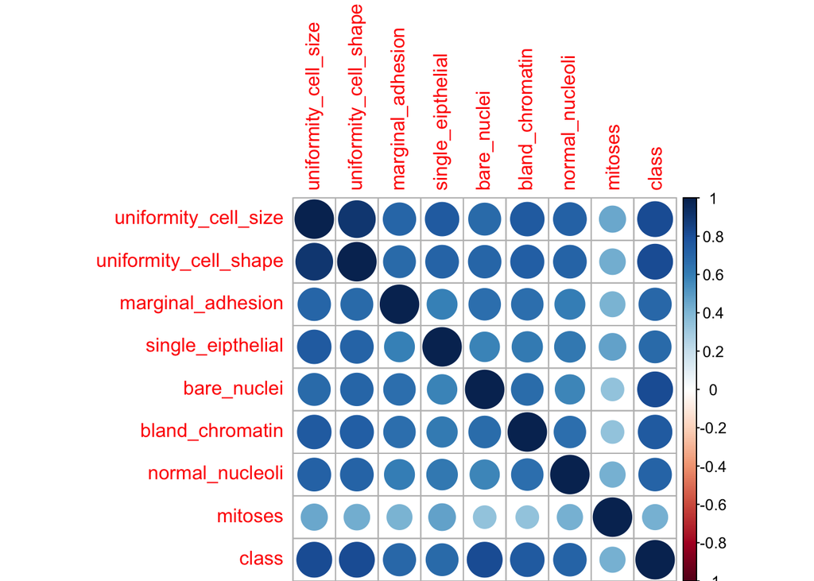

Now that we know about the presence of relationship between available variables, we want to produce a representation to visualize the average values for class of each of the criteria in the study. While one criterion isn’t enough to properly predict class, one can get a better idea for class if a few criteria skew higher or lower. The following graph gives a good idea of how the average data point lies in each class.

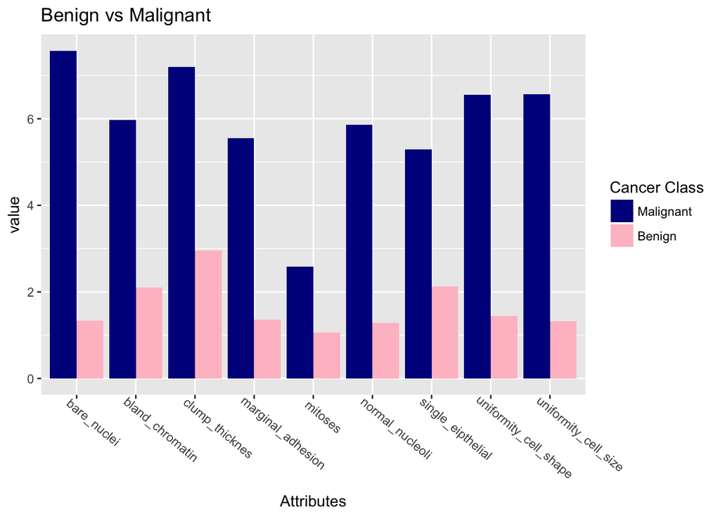

For clarification, in the following graph we can better appreciate the frequency of cases per class.

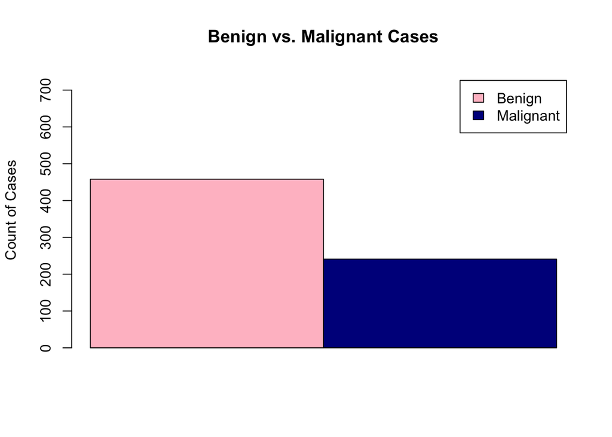

# Modeling as input for Visualizations

The p-values of several variables are too high (>0.05) for us to trust them in further analysis, e.g. uniformity_cell_shape. But marginal_adhesion, clump thickness, bare_nuclei, and bland_chromatin all add information about the target variable at a cionfidence level we are comfortable with.

```
##
## Call:
## glm(formula = as.factor(noNA.mydat$class) ~ marginal_adhesion +
##     clump_thicknes + uniformity_cell_size + uniformity_cell_shape +
##     single_eipthelial + bare_nuclei + bland_chromatin + normal_nucleoli +
##     mitoses, family = binomial, data = noNA.mydat)
##
## Deviance Residuals:
##     Min       1Q   Median       3Q      Max
## -3.3310  -0.1269  -0.0659   0.0273   2.3954
##
## Coefficients:
##                       Estimate Std. Error z value Pr(>|z|)
## (Intercept)           -9.71454    1.07434  -9.042  < 2e-16 ***
## marginal_adhesion      0.23762    0.11672   2.036  0.04176 *
## clump_thicknes         0.53465    0.13488   3.964 7.38e-05 ***
## uniformity_cell_size   0.01128    0.19321   0.058  0.95344
## uniformity_cell_shape  0.32377    0.21390   1.514  0.13011
## single_eipthelial      0.05832    0.15255   0.382  0.70222
## bare_nuclei            0.42816    0.09051   4.730 2.24e-06 ***
## bland_chromatin        0.41213    0.15693   2.626  0.00864 **
## normal_nucleoli        0.15824    0.10414   1.519  0.12864
## mitoses                0.53584    0.30698   1.746  0.08089 .
## ---
## Signif. codes:  0 '***' 0.001 '**' 0.01 '*' 0.05 '.' 0.1 ' ' 1
##
## (Dispersion parameter for binomial family taken to be 1)
##
##     Null deviance: 900.53  on 698  degrees of freedom
## Residual deviance: 113.09  on 689  degrees of freedom
## AIC: 133.09
##
## Number of Fisher Scoring iterations: 8
```

Removing the variables with high p-scores marginally increases AIC but is likely a better model for deployment.

```
##
## Call:
## glm(formula = as.factor(noNA.mydat$class) ~ marginal_adhesion +
##     clump_thicknes + bare_nuclei + bland_chromatin, family = binomial,
##     data = noNA.mydat)
##
## Deviance Residuals:
##     Min       1Q   Median       3Q      Max
## -3.6017  -0.1524  -0.0639   0.0271   2.4503
##
## Coefficients:
##                   Estimate Std. Error z value Pr(>|z|)
## (Intercept)       -9.81375    0.95400 -10.287  < 2e-16 ***
## marginal_adhesion  0.34758    0.10606   3.277  0.00105 **
## clump_thicknes     0.79920    0.12001   6.660 2.74e-11 ***
## bare_nuclei        0.51352    0.08719   5.889 3.88e-09 ***
## bland_chromatin    0.65315    0.13787   4.737 2.16e-06 ***
## ---
## Signif. codes:  0 '***' 0.001 '**' 0.01 '*' 0.05 '.' 0.1 ' ' 1
##
## (Dispersion parameter for binomial family taken to be 1)
##
##     Null deviance: 900.53  on 698  degrees of freedom
## Residual deviance: 134.46  on 694  degrees of freedom
## AIC: 144.46
##
## Number of Fisher Scoring iterations: 8
```

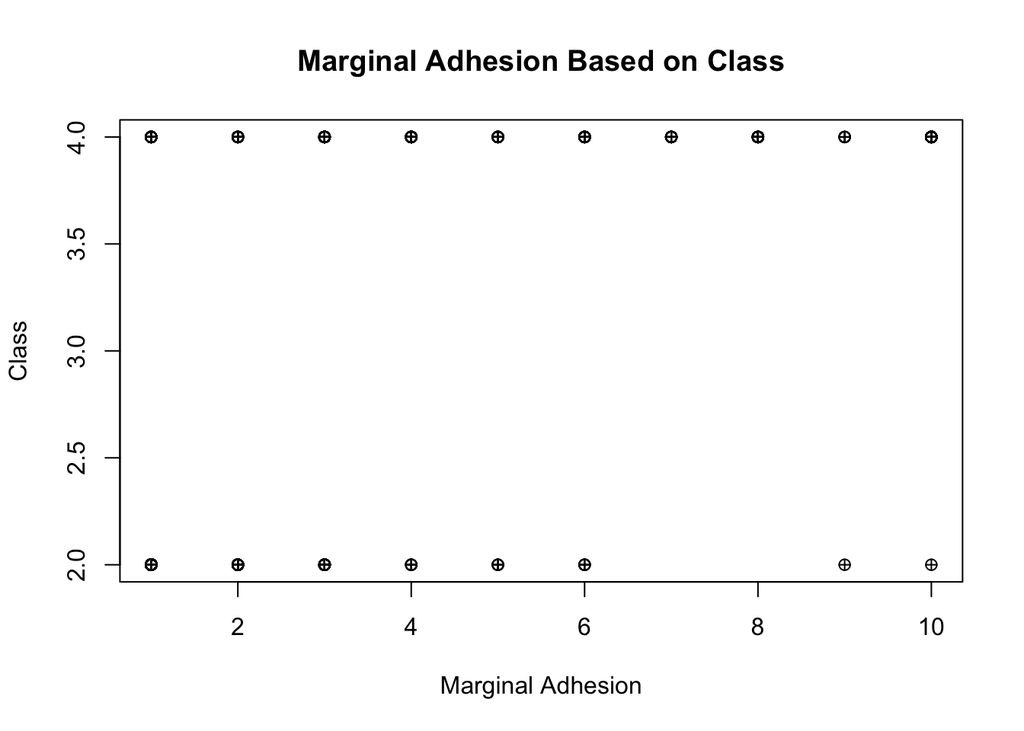

The following graphs visualize how some of the more significant criteria can both be used to predict class. Tumor status is denoted by both color and shape to make it easier to read. The first graph below shows that while high scores in both marginal adhesions and clump thickness are more likely to predict a malignant case (and vice versa), it also reveals that looking at these two criteria won’t absolutely predict class. There were multiple data points scoring over 5.0 that still resulted in benign cases. This visualization also shows which intervals will predict the highest percentage of benign and malignant cases.

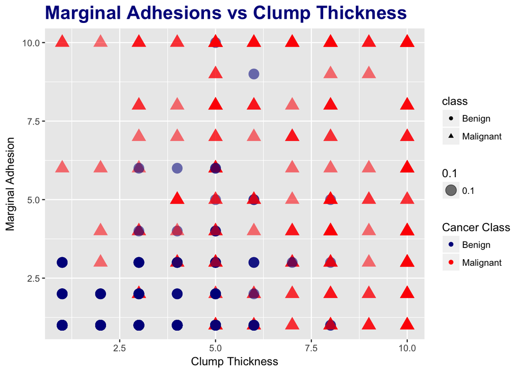

The next graph investigates the relationships between bland_chromatin and bare_nuclei, and their ability to help medical personnel predict breast cancer. Both show the same relationship to class as the previously tested variables: extreme high scores indicate malignancy. Ideally, there would be clear boundaries between benign and malignant cases on the scales, but as we see again, there are cases where mid-range scores in both criteria could indicate a benign OR a malignant tumor. It is, therefore, likely that no simple schema can be created as a prediction tool for breast cancer, and that we would need to rely on multiple variables to make the prediction.

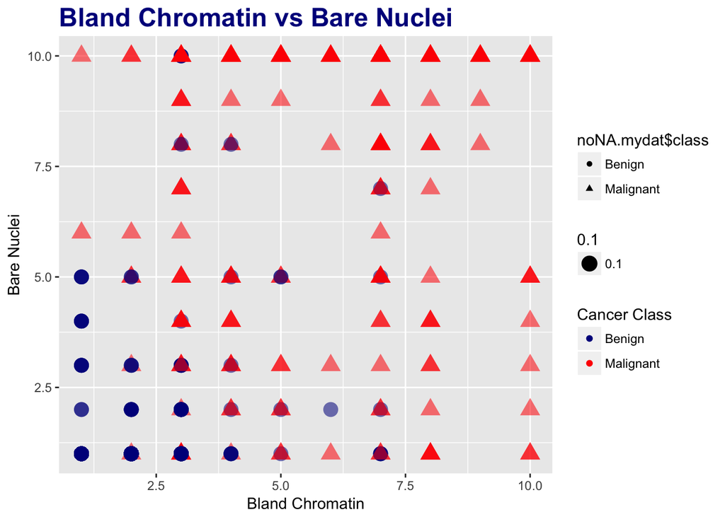

# Conclusion

> While intuitive, neither 2x2 visualization supports a through analysis of tumor malignancy in breast cancer. As such we would need to revert to the four-variable logit model we derived earlier to support further investigation of tumor formation and diagnosis in the hospital environment. That said, in **any ONE** of the four variables we identified in the logistic regression (marginal adhesion, clum thickness, bland chromatin, bare nuclei), one pattern was clear: higher than moderate scores increase the chance of malignancy.